# Data Science Applied to Ag - Final Project - Design

Author

Aytan Pirverdiyeva & Ruben Vinueza

# 1 Instructions

This file contains both the **instructions** for the mid-term project and placeholders for your code. You are required to use this file to produce code, output, and answers to the questions below.

Besides simply creating output, make sure to interpret the output. You will need to create tables and/or plots to arrive at the answers, and then comment on what you found below it.

To get you setup, you will need to:

- Student #1: create a repository on your GitHub account. You can call this repository “2025dsa_finalproject_groupX”, **where X is the number of your group**. Make it public, add a README, add a .gitignore for R.
- Student #1: follow the steps we did in class to start a new RStudio project with version control.
- Student #1: in your computer, create the sub-folders code, data, output, and move your data set into the `data` folder. Also, student 1 moves this current script into the `code` folder. Do a git stage, commit, push.
- Student #1: on GitHub, go the repository settings and invite your partner to be a collaborator in the repository. That will give them push permission.
- Now, both students should clone this repository on their computers like we did in class. Make sure this step works well and that you can pull and push from GitHub.
- Student 2, after cloning, does a git pull to get all these updates on their computer.
- Student 1 and 2 work together to update the README file. README files should explain what the repository is about, the goals of that project, who is working in it, and any other important details you may find.

# 2 Introduction

Describe here the introduction of your problem. Consider this as a shortened version of your paper, where you will briefly discuss in 3-4 paragraphs what is the issue/gap in literature, and how the data you collected will help answer this gap.

**Introduction**

In the fresh produce industry, increased concerns of cross-contamination from food contact surfaces (FCS) regularly encountered during postharvest handling have led many to scrutinize their sanitation regimes. Toward this goal, developing efficient, low-cost, and appropriate sanitation techniques while considering the nature of the FCS material needs to be broadly studied.

# 3 Hypothesis and objectives

Describe here your hypothesis, followed by your objectives. Make sure your hypothesis are testable and bold, and objectives are clear.

**Variables and Research Hypotheses**

*Hypothesis 1:* Chemical sanitizing agents will be effective in inactivating *Listeria*. Treating food contact surfaces with commercially available chemicals containing chlorine and peroxyacetic acid (PAA) as a source of reactive oxygen species will decrease the potential pathogens *via* oxidizing essential parts of bacteria.

Previously reported studies have shown that pathogenic bacteria, particularly *Listeria*, are considerably less prevalent on food contact surfaces that have been treated with specific chemical agents such as peroxyacetic acid and chlorine versus untreated surfaces. As a result, these agents are suitable for sanitization procedures in food safety measures because of their quantifiable and considerable efficacy.

*Hypothesis 2:* Surface material characteristics will impact the efficacy of cleaning and sanitization approaches evaluated. As a variable, the kind of surface material - such as closed-cell foam, polyvinyl chloride (PVC), and interlocking belt-polypropylene - affects how the sanitization procedure turns out.

Depending on the physical and chemical nature of the surface materials – such as porosity, hydrophobicity, and surface roughness different sanitization techniques will no longer effectively eradicate *Listeria* from food contact surfaces. Materials that are resistant to bacterial contamination and have varying levels of sanitization efficiency, such as foam, PVC, and interlocking belt-polypropylene, will be considered when selecting materials for food processing facilities that are safer.

# 4 Material and Methods

Describe here your overall material and methods as it pertains to the analysis you will conduct, including study description, site/setup description, what equipment was used, etc. just like you would in a paper. Make sure to clearly explain what was measured and how.

*Material and Methods*

Three commonly used FCS materials were selected: interlocking belt (IB) made of polypropylene, polyvinyl chloride (PVC) rollers, and closed-cell foam (CF). Coupons were spot inoculated with ~8 log CFU of an Listeria monocytogenes (LM) cocktail consisting of five produce-related outbreak strains adapted to 80 ppm rifampicin and allowed to dry for 1 h in a biosafety cabinet. FCSs were cleaned with a detergent applied as a liquid with manual brushing or as a foam, followed by rinsing and sanitization with free chlorine (350 ppm), peroxyacetic acid (350 ppm), or no sanitizer. A control group received no treatment. The coupons were neutralized in 100 mL Dey-Engley broth with 0.1 % (v/v) Tween 80 and spiral plated onto Tryptic Soy Agar with Rifampicin (TSAR). Plates were incubated at 35 °C and enumerated after 48 h.

## 4.1 Study design

Clearly describe your study design here, including treatment design (which factors and levels, the hierarchy among them, etc.), and your experimental design (number of reps/blocks, how was randomization performed, etc.), as we talked about in class.

*Study Design*

**Treatment Desig** This was a two-factor factorial experiment with both factors treated as fixed effects.

**Note**: Detergent or foam alone was not tested — they were always followed by either a DI rinse or a sanitizer (chlorine or PAA).

This design was fully crossed: each treatment was applied to each surface type.

**Experimental Design**

**Randomization** Treatments and materials were applied in a randomized order, and sample enumeration steps were randomized to reduce bias.

# 5 Statistical analysis

Describe here your statistical analysis, including what type of ANOVA model you ran (based on the design above), what was your response variable, what were your explanatory variables and how were the explanatory variables treated (random or fixed). Provide your alpha level. Explain which function from which package you used to analyze this data. Explain how you checked linear model assumptions and whether or not they were met. Overall, make sure you explain in sufficient detail that, if given your data, a knowledgeable person would be able to reproduce your analysis exactly.

*Statistical analysis* A two-way ANOVA was used with: - Fixed effects: Treatment, Material, and their interaction - Response variable: Log reduction CFU/coupon

A mixed-effects model (with Biological Replication as a random effect) may be used to account for block effects. Post hoc pairwise comparisons were conducted using emmeans or Tukey-adjusted tests. Residual diagnostics were used to verify assumptions of normality and homogeneity of variance.

**Script** #Setup

```r
library(tidyverse)
library(lme4)
library(lmerTest)
library(emmeans)
library(car)
library(ggplot2)
library(dplyr)
library(stringr)
library(forcats)
```

# 6 1.Load and Clean data

```r
data_raw <-read.csv("../data/Listeria for R.csv")

data_raw
```

```
          Date           Treatment                         Material
1   11/18/2024      Det+Chlorine                               Foam
2   11/18/2024      Det+Chlorine                               Foam
3   11/18/2024      Det+Chlorine                               Foam
4   11/18/2024      Det+Chlorine                               Foam
5   11/18/2024      Det+Chlorine                               Foam
6   11/18/2024      Det+Chlorine                               Foam
7   11/21/2024       Det+Chlorine                              Foam
8   11/21/2024       Det+Chlorine                              Foam
9   11/21/2024       Det+Chlorine                              Foam
10  11/21/2024       Det+Chlorine                              Foam
11  11/21/2024       Det+Chlorine                              Foam
12  11/21/2024       Det+Chlorine                              Foam
13  10/25/2024       Det+Chlorine                              Foam
14  10/25/2024       Det+Chlorine                              Foam
```

[output cut: 743 more lines]

```r
summary(data_raw)
```

```
     Date            Treatment           Material
 Length:378         Length:378         Length:378
 Class :character   Class :character   Class :character
 Mode  :character   Mode  :character   Mode  :character



 Biological.Replication Population..Log.CFU.coupon.
 Min.   :1              Min.   :3.000
 1st Qu.:1              1st Qu.:4.530
 Median :2              Median :5.295
 Mean   :2              Mean   :5.551
 3rd Qu.:3              3rd Qu.:6.365
 Max.   :3              Max.   :8.550
```

#Check column names

```r
data_clean <- data_raw %>%
  janitor::clean_names() %>%
  select(date, treatment, material, biological_replication, population_log_cfu_coupon) %>%
  mutate(
    treatment = str_trim(treatment),
    material = str_trim(material),
    biological_replication = as.factor(biological_replication)
  ) %>%
  drop_na()
data_clean
```

```
          date         treatment                         material
1   11/18/2024      Det+Chlorine                             Foam
2   11/18/2024      Det+Chlorine                             Foam
3   11/18/2024      Det+Chlorine                             Foam
4   11/18/2024      Det+Chlorine                             Foam
5   11/18/2024      Det+Chlorine                             Foam
6   11/18/2024      Det+Chlorine                             Foam
7   11/21/2024      Det+Chlorine                             Foam
8   11/21/2024      Det+Chlorine                             Foam
9   11/21/2024      Det+Chlorine                             Foam
10  11/21/2024      Det+Chlorine                             Foam
11  11/21/2024      Det+Chlorine                             Foam
12  11/21/2024      Det+Chlorine                             Foam
13  10/25/2024      Det+Chlorine                             Foam
14  10/25/2024      Det+Chlorine                             Foam
```

[output cut: 743 more lines]

```r
str(data_clean)
```

```
'data.frame':   378 obs. of  5 variables:
 $ date                     : chr  "11/18/2024" "11/18/2024" "11/18/2024" "11/18/2024" ...
 $ treatment                : chr  "Det+Chlorine" "Det+Chlorine" "Det+Chlorine" "Det+Chlorine" ...
 $ material                 : chr  "Foam" "Foam" "Foam" "Foam" ...
 $ biological_replication   : Factor w/ 3 levels "1","2","3": 1 1 1 1 1 1 2 2 2 2 ...
 $ population_log_cfu_coupon: num  5.1 5.45 5.36 5.31 5 4.96 3.48 3.01 4.12 4.26 ...
```

## 6.1 Descriptive summary for each treatment × material × bio rep

```r
summary_stats <- data_clean %>%
  group_by(treatment, material, biological_replication) %>%
  summarise(
    mean_log_cfu = mean(population_log_cfu_coupon),
    sd_log_cfu = sd(population_log_cfu_coupon),
    .groups = "drop"
  )
summary_stats
```

```
# A tibble: 63 × 5
   treatment    material          biological_replication mean_log_cfu sd_log_cfu
   <chr>        <chr>             <fct>                         <dbl>      <dbl>
 1 Det+Chlorine Foam              1                              5.20     0.204
 2 Det+Chlorine Foam              2                              3.48     0.583
 3 Det+Chlorine Foam              3                              3.97     0.643
 4 Det+Chlorine Interlocking bel… 1                              6.14     0.0983
 5 Det+Chlorine Interlocking bel… 2                              6.03     0.458
 6 Det+Chlorine Interlocking bel… 3                              6.40     0.421
 7 Det+Chlorine PVC               1                              3.90     0.817
 8 Det+Chlorine PVC               2                              4.85     0.716
 9 Det+Chlorine PVC               3                              4.35     0.596
10 Det+SaniDate Foam              1                              5.10     0.575
# ℹ 53 more rows
```

## 6.2 Mixed-effects model: Treatment × Material, with random intercept for Bio Rep

```r
# Changing to sum-to-zero contrast
options(contrasts = c("contr.sum", "contr.poly"))

# Model fitting
mix_mod <- lmer(mean_log_cfu ~ material*treatment +
                      (1|biological_replication),
                     data = summary_stats
                     )

# Summary
summary(mix_mod)
```

```
Linear mixed model fit by REML. t-tests use Satterthwaite's method [
lmerModLmerTest]
Formula: mean_log_cfu ~ material * treatment + (1 | biological_replication)
   Data: summary_stats

REML criterion at convergence: 116.9

Scaled residuals:
     Min       1Q   Median       3Q      Max
-1.94062 -0.51356  0.03696  0.40128  1.81150

Random effects:
 Groups                 Name        Variance Std.Dev.
 biological_replication (Intercept) 0.03885  0.1971
 Residual                           0.26877  0.5184
Number of obs: 63, groups:  biological_replication, 3

Fixed effects:
                       Estimate Std. Error         df t value Pr(>|t|)
(Intercept)           5.5511111  0.1312061  1.9999995  42.308 0.000558 ***
material1            -0.5630159  0.0923708 40.0000003  -6.095 3.47e-07 ***
material2             0.7275397  0.0923708 40.0000003   7.876 1.16e-09 ***
treatment1           -0.6272222  0.1599909 40.0000003  -3.920 0.000338 ***
treatment2           -0.9301852  0.1599909 40.0000003  -5.814 8.63e-07 ***
treatment3           -0.3818519  0.1599909 40.0000003  -2.387 0.021819 *
treatment4           -0.2146296  0.1599909 40.0000003  -1.342 0.187321
treatment5           -0.8522222  0.1599909 40.0000003  -5.327 4.16e-06 ***
treatment6            0.2968519  0.1599909 40.0000003   1.855 0.070914 .
material1:treatment1 -0.1447619  0.2262612 40.0000003  -0.640 0.525951
material2:treatment1  0.5396825  0.2262612 40.0000003   2.385 0.021896 *
material1:treatment2  0.4232011  0.2262612 40.0000003   1.870 0.068757 .
material2:treatment2  0.0004233  0.2262612 40.0000003   0.002 0.998517
material1:treatment3  0.1204233  0.2262612 40.0000003   0.532 0.597510
material2:treatment3  0.1015344  0.2262612 40.0000003   0.449 0.656035
material1:treatment4 -0.1006878  0.2262612 40.0000003  -0.445 0.658714
material2:treatment4 -0.1406878  0.2262612 40.0000003  -0.622 0.537606
material1:treatment5 -0.4808730  0.2262612 40.0000003  -2.125 0.039788 *
material2:treatment5  0.1807937  0.2262612 40.0000003   0.799 0.428982
material1:treatment6 -0.3399471  0.2262612 40.0000003  -1.502 0.140834
material2:treatment6 -0.0543915  0.2262612 40.0000003  -0.240 0.811254
---
Signif. codes:  0 '***' 0.001 '**' 0.01 '*' 0.05 '.' 0.1 ' ' 1
```

```
Correlation matrix not shown by default, as p = 21 > 12.
Use print(x, correlation=TRUE)  or
    vcov(x)        if you need it
```

#Interpretation:

##These results support the idea that both treatment type and surface material significantly influence Listeria monocytogenes reduction. The presence of significant coefficients for materials and several treatments implies that these factors affect microbial survival independently, and possibly interactively.

## 6.3 Estimated marginal means

```r
emmeans_mixed <- emmeans(mix_mod, ~ treatment * material)

emmeans_mixed
```

```
 treatment         material                         emmean   SE   df lower.CL
 Det+Chlorine      Foam                               4.22 0.32 31.8     3.56
 Det+SaniDate      Foam                               4.48 0.32 31.8     3.83
 Det+Water         Foam                               4.73 0.32 31.8     4.07
 Foam+Chlorine     Foam                               4.67 0.32 31.8     4.02
 Foam+SaniDate     Foam                               3.65 0.32 31.8     3.00
 Foam+Water        Foam                               4.95 0.32 31.8     4.29
 Without Treatment Foam                               8.22 0.32 31.8     7.57
 Det+Chlorine      Interlocking belt- polypropylene   6.19 0.32 31.8     5.54
 Det+SaniDate      Interlocking belt- polypropylene   5.35 0.32 31.8     4.70
 Det+Water         Interlocking belt- polypropylene   6.00 0.32 31.8     5.35
 Foam+Chlorine     Interlocking belt- polypropylene   5.92 0.32 31.8     5.27
 Foam+SaniDate     Interlocking belt- polypropylene   5.61 0.32 31.8     4.95
 Foam+Water        Interlocking belt- polypropylene   6.52 0.32 31.8     5.87
 Without Treatment Interlocking belt- polypropylene   8.36 0.32 31.8     7.71
 Det+Chlorine      PVC                                4.36 0.32 31.8     3.71
 Det+SaniDate      PVC                                4.03 0.32 31.8     3.38
 Det+Water         PVC                                4.78 0.32 31.8     4.13
 Foam+Chlorine     PVC                                5.41 0.32 31.8     4.76
 Foam+SaniDate     PVC                                4.83 0.32 31.8     4.18
 Foam+Water        PVC                                6.08 0.32 31.8     5.43
 Without Treatment PVC                                8.20 0.32 31.8     7.55
 upper.CL
     4.87
     5.13
     5.38
     5.33
     4.31
     5.60
     8.87
     6.84
     6.00
     6.65
     6.58
     6.26
     7.17
     9.01
     5.02
     4.69
     5.44
     6.07
     5.49
     6.73
     8.85

Degrees-of-freedom method: kenward-roger
Confidence level used: 0.95
```

#3.Confidence intervals (CI) are provided in columns lower.CL and upper.CL. Non-overlapping CIs between treatments and materials suggest statistically significant differences.

## 6.4 4. Type III ANOVA table and Main Effects (if Interaction is Significant)

```r
interaction_test <- anova(mix_mod, type = 3)
print(interaction_test)
```

```
Type III Analysis of Variance Table with Satterthwaite's method
                   Sum Sq Mean Sq NumDF DenDF F value    Pr(>F)
material           18.341  9.1704     2    40 34.1199 2.257e-09 ***
treatment          86.445 14.4075     6    40 53.6056 < 2.2e-16 ***
material:treatment  6.884  0.5737    12    40  2.1344   0.03637 *
---
Signif. codes:  0 '***' 0.001 '**' 0.01 '*' 0.05 '.' 0.1 ' ' 1
```

#Answer ##Main effects of both treatment and material are highly significant, indicating that each independently influences the reduction of Listeria monocytogenes (log CFU/coupon).

##The interaction between treatment and material is also statistically significant (p = 0.036). This confirms that the effectiveness of each treatment depends on the surface material used.

##These findings support the need to explore which treatments perform best on which surfaces, using post hoc tests and estimated marginal means for deeper insights.

## 6.5 5. Post hoc comparisons with Tukey adjustment

```r
emmeans_mix <- emmeans(mix_mod, ~ treatment * material)
pairs(emmeans_mix, adjust = "tukey")
```

```
 contrast
 (Det+Chlorine Foam) - (Det+SaniDate Foam)
 (Det+Chlorine Foam) - (Det+Water Foam)
 (Det+Chlorine Foam) - (Foam+Chlorine Foam)
 (Det+Chlorine Foam) - (Foam+SaniDate Foam)
 (Det+Chlorine Foam) - (Foam+Water Foam)
 (Det+Chlorine Foam) - Without Treatment Foam
 (Det+Chlorine Foam) - (Det+Chlorine Interlocking belt- polypropylene)
 (Det+Chlorine Foam) - (Det+SaniDate Interlocking belt- polypropylene)
 (Det+Chlorine Foam) - (Det+Water Interlocking belt- polypropylene)
 (Det+Chlorine Foam) - (Foam+Chlorine Interlocking belt- polypropylene)
 (Det+Chlorine Foam) - (Foam+SaniDate Interlocking belt- polypropylene)
 (Det+Chlorine Foam) - (Foam+Water Interlocking belt- polypropylene)
 (Det+Chlorine Foam) - (Without Treatment Interlocking belt- polypropylene)
 (Det+Chlorine Foam) - (Det+Chlorine PVC)
 (Det+Chlorine Foam) - (Det+SaniDate PVC)
 (Det+Chlorine Foam) - (Det+Water PVC)
 (Det+Chlorine Foam) - (Foam+Chlorine PVC)
 (Det+Chlorine Foam) - (Foam+SaniDate PVC)
 (Det+Chlorine Foam) - (Foam+Water PVC)
 (Det+Chlorine Foam) - Without Treatment PVC
 (Det+SaniDate Foam) - (Det+Water Foam)
 (Det+SaniDate Foam) - (Foam+Chlorine Foam)
 (Det+SaniDate Foam) - (Foam+SaniDate Foam)
 (Det+SaniDate Foam) - (Foam+Water Foam)
 (Det+SaniDate Foam) - Without Treatment Foam
 (Det+SaniDate Foam) - (Det+Chlorine Interlocking belt- polypropylene)
 (Det+SaniDate Foam) - (Det+SaniDate Interlocking belt- polypropylene)
 (Det+SaniDate Foam) - (Det+Water Interlocking belt- polypropylene)
 (Det+SaniDate Foam) - (Foam+Chlorine Interlocking belt- polypropylene)
 (Det+SaniDate Foam) - (Foam+SaniDate Interlocking belt- polypropylene)
 (Det+SaniDate Foam) - (Foam+Water Interlocking belt- polypropylene)
 (Det+SaniDate Foam) - (Without Treatment Interlocking belt- polypropylene)
 (Det+SaniDate Foam) - (Det+Chlorine PVC)
 (Det+SaniDate Foam) - (Det+SaniDate PVC)
 (Det+SaniDate Foam) - (Det+Water PVC)
 (Det+SaniDate Foam) - (Foam+Chlorine PVC)
 (Det+SaniDate Foam) - (Foam+SaniDate PVC)
 (Det+SaniDate Foam) - (Foam+Water PVC)
 (Det+SaniDate Foam) - Without Treatment PVC
```

[output cut: 370 more lines]

```
  -2.0450 0.423 40  -4.831  0.0030
  -4.1678 0.423 40  -9.846  <.0001
  -0.6306 0.423 40  -1.490  0.9937
  -0.0517 0.423 40  -0.122  1.0000
  -1.2950 0.423 40  -3.059  0.2657
  -3.4178 0.423 40  -8.074  <.0001
   0.5789 0.423 40   1.368  0.9977
  -0.6644 0.423 40  -1.570  0.9888
  -2.7872 0.423 40  -6.585  <.0001
  -1.2433 0.423 40  -2.937  0.3297
  -3.3661 0.423 40  -7.952  <.0001
  -2.1228 0.423 40  -5.015  0.0018

Degrees-of-freedom method: kenward-roger
P value adjustment: tukey method for comparing a family of 21 estimates
```

# 7 Step 6: Checking model assumptions

- Independence (no pattern)
- Variance homogeneity (homoscedasticity)
- Normality
- Outlier detection (< -3 or > 3)

## 7.1 Extracting residuals

First, extract our model residuals, and also create studentized residuals.

```r
library(broom.mixed)
mix_mod_resid <- augment(mix_mod) %>%
  mutate(.studresid=rstudent(mix_mod))

mix_mod_resid
```

```
# A tibble: 63 × 16
   mean_log_cfu material  treatment biological_replication .fitted  .resid  .hat
          <dbl> <fct>     <fct>     <fct>                    <dbl>   <dbl> <dbl>
 1         5.20 Foam      Det+Chlo… 1                         4.30  0.896  0.357
 2         3.48 Foam      Det+Chlo… 2                         4.02 -0.541  0.357
 3         3.97 Foam      Det+Chlo… 3                         4.33 -0.355  0.357
 4         6.14 Interloc… Det+Chlo… 1                         6.28 -0.134  0.357
 5         6.03 Interloc… Det+Chlo… 2                         5.99  0.0389 0.357
 6         6.40 Interloc… Det+Chlo… 3                         6.30  0.0947 0.357
 7         3.90 PVC       Det+Chlo… 1                         4.45 -0.554  0.357
 8         4.85 PVC       Det+Chlo… 2                         4.17  0.682  0.357
 9         4.35 PVC       Det+Chlo… 3                         4.48 -0.129  0.357
10         5.10 Foam      Det+Sani… 1                         4.57  0.530  0.357
# ℹ 53 more rows
# ℹ 9 more variables: .cooksd <dbl>, .fixed <dbl>, .mu <dbl>, .offset <dbl>,
#   .sqrtXwt <dbl>, .sqrtrwt <dbl>, .weights <dbl>, .wtres <dbl>,
#   .studresid <dbl>
```

### 7.1.1 Random effects are iid ~ N(0,var_a)

```r
randeff_rep <- ranef(mix_mod) [[1]]

randeff_rep
```

```
  (Intercept)
1  0.08417286
2 -0.19670181
3  0.11252896
```

#Answer ##The random intercepts for biological replication varied only modestly (ranging from −0.20 to +0.11), indicating that variation among replicates was minor. This justifies treating biological replication as a random effect in the mixed-effects model to account for repeated measures without influencing treatment inference.

# 8 QQ plot to check for assumptions on random effects.

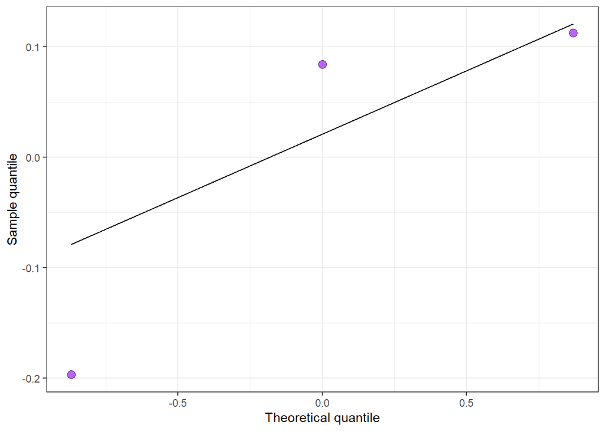

```r
ggplot(randeff_rep, aes(sample=`(Intercept)`))+
  stat_qq(  shape = 21,
            fill = "purple",
            size = 3,
            alpha = .7
  )+
  stat_qq_line()+
  labs(x = "Theoretical quantile",
       y = "Sample quantile")+
  theme_bw()
```

#Answer: ##Nothing to worry here, especially since we only have 3 points.

### 8.0.1 Within-group errors are iid ~ N(0, var_e)

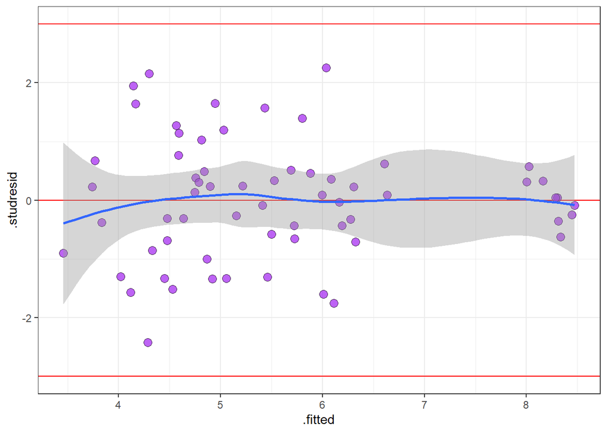

```r
ggplot(mix_mod_resid, aes(x=.fitted, y=.studresid))+
  geom_hline(yintercept = 0, color="red")+
  geom_point(shape = 21,
             fill = "purple",
             size = 3,
             alpha = .7)+
  geom_smooth()+
  geom_hline(yintercept = c(-3,3), color = "red")+
  theme_bw()
```

#Answer:

**Independence**: seems liker there is a potential pattern, but since error bands comprise 0 on the y-axis, I’m not worried.

- **Variance homoscedastic**: seems constant across the x-axis.
- **Outliers**: nothing outside the -3,3 boundaries.

## 8.1 QQ plot

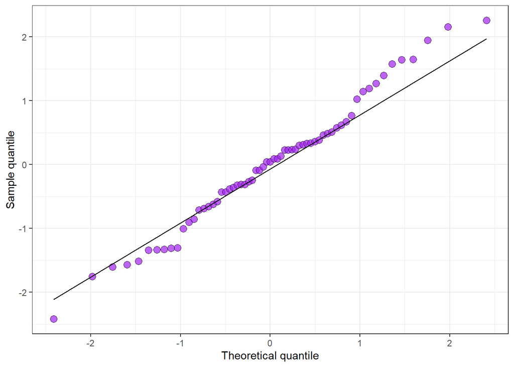

```r
ggplot(mix_mod_resid, aes(sample=.studresid))+
  stat_qq(  shape = 21,
            fill = "purple",
            size = 3,
            alpha = .7
  )+
  stat_qq_line()+
  labs(x = "Theoretical quantile",
       y = "Sample quantile")+
  theme_bw()
```

#Answer: ##The QQ plot of standardized residuals showed that the points aligned closely along the 45-degree reference line, indicating that the residuals are approximately normally distributed. This supports the validity of the normality assumption required for the linear mixed-effects model.

## 8.2 Density plot

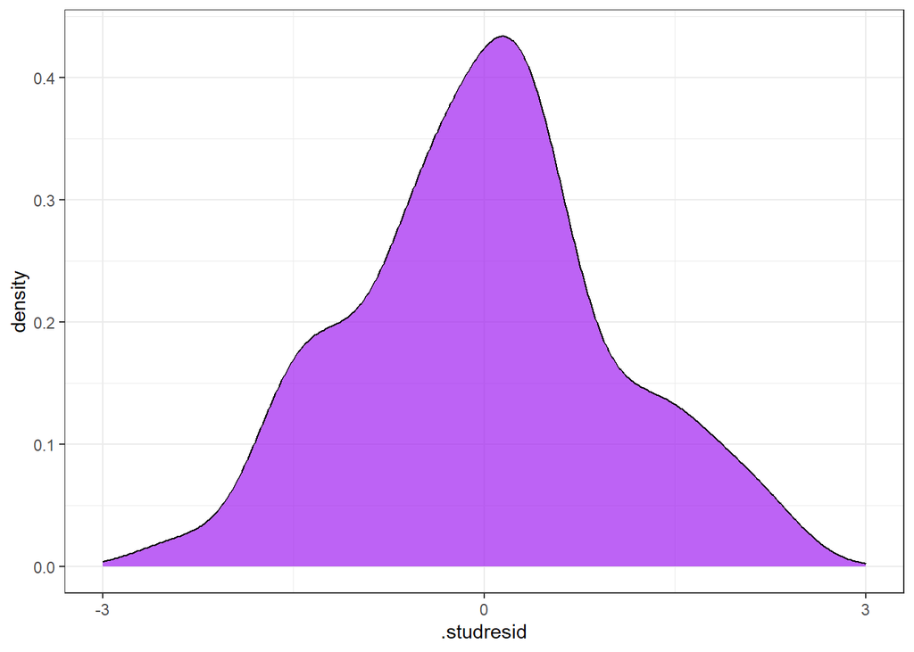

```r
ggplot(mix_mod_resid, aes(x=.studresid))+
  geom_density(color = "black",
               fill = "purple",
               alpha = .7)+
  scale_x_continuous(breaks = c(-3,0,3), limits = c(-3,3))+
  theme_bw()
```

#Answer: **Normality**: residuals seem normal.

# 9 7. Summary Output

```r
summary(mix_mod)
```

```
Linear mixed model fit by REML. t-tests use Satterthwaite's method [
lmerModLmerTest]
Formula: mean_log_cfu ~ material * treatment + (1 | biological_replication)
   Data: summary_stats

REML criterion at convergence: 116.9

Scaled residuals:
     Min       1Q   Median       3Q      Max
-1.94062 -0.51356  0.03696  0.40128  1.81150

Random effects:
 Groups                 Name        Variance Std.Dev.
 biological_replication (Intercept) 0.03885  0.1971
 Residual                           0.26877  0.5184
Number of obs: 63, groups:  biological_replication, 3

Fixed effects:
                       Estimate Std. Error         df t value Pr(>|t|)
(Intercept)           5.5511111  0.1312061  1.9999995  42.308 0.000558 ***
material1            -0.5630159  0.0923708 40.0000003  -6.095 3.47e-07 ***
material2             0.7275397  0.0923708 40.0000003   7.876 1.16e-09 ***
treatment1           -0.6272222  0.1599909 40.0000003  -3.920 0.000338 ***
treatment2           -0.9301852  0.1599909 40.0000003  -5.814 8.63e-07 ***
treatment3           -0.3818519  0.1599909 40.0000003  -2.387 0.021819 *
treatment4           -0.2146296  0.1599909 40.0000003  -1.342 0.187321
treatment5           -0.8522222  0.1599909 40.0000003  -5.327 4.16e-06 ***
treatment6            0.2968519  0.1599909 40.0000003   1.855 0.070914 .
material1:treatment1 -0.1447619  0.2262612 40.0000003  -0.640 0.525951
material2:treatment1  0.5396825  0.2262612 40.0000003   2.385 0.021896 *
material1:treatment2  0.4232011  0.2262612 40.0000003   1.870 0.068757 .
material2:treatment2  0.0004233  0.2262612 40.0000003   0.002 0.998517
material1:treatment3  0.1204233  0.2262612 40.0000003   0.532 0.597510
material2:treatment3  0.1015344  0.2262612 40.0000003   0.449 0.656035
material1:treatment4 -0.1006878  0.2262612 40.0000003  -0.445 0.658714
material2:treatment4 -0.1406878  0.2262612 40.0000003  -0.622 0.537606
material1:treatment5 -0.4808730  0.2262612 40.0000003  -2.125 0.039788 *
material2:treatment5  0.1807937  0.2262612 40.0000003   0.799 0.428982
material1:treatment6 -0.3399471  0.2262612 40.0000003  -1.502 0.140834
material2:treatment6 -0.0543915  0.2262612 40.0000003  -0.240 0.811254
---
Signif. codes:  0 '***' 0.001 '**' 0.01 '*' 0.05 '.' 0.1 ' ' 1
```

```
Correlation matrix not shown by default, as p = 21 > 12.
Use print(x, correlation=TRUE)  or
    vcov(x)        if you need it
```

# 10 8. Save summary if needed

```r
summary_df <- broom::tidy(mix_mod)
write_csv(summary_df, "../output/summary_stats.csv")
```

# 11 9.Create dataframe for plotting

```r
emm_df <- as.data.frame(emmeans_mixed) %>%
  mutate(
    group = case_when(
      str_detect(treatment, "Chlorine") ~ "Chlorine",
      str_detect(treatment, "PAA") | str_detect(treatment, "SaniDate") ~ "PAA",
      str_detect(treatment, "Water") ~ "Water",
      str_detect(treatment, "Without") ~ "Control",
      TRUE ~ "Other"
    ),
    treatment_material = paste(treatment, material),
    treatment_material = fct_reorder(treatment_material, emmean)
  )

emm_df
```

```
           treatment                         material   emmean        SE
1       Det+Chlorine                             Foam 4.216111 0.3202165
2       Det+SaniDate                             Foam 4.481111 0.3202165
3          Det+Water                             Foam 4.726667 0.3202165
4      Foam+Chlorine                             Foam 4.672778 0.3202165
5      Foam+SaniDate                             Foam 3.655000 0.3202165
6         Foam+Water                             Foam 4.945000 0.3202165
7  Without Treatment                             Foam 8.220000 0.3202165
8       Det+Chlorine Interlocking belt- polypropylene 6.191111 0.3202165
9       Det+SaniDate Interlocking belt- polypropylene 5.348889 0.3202165
10         Det+Water Interlocking belt- polypropylene 5.998333 0.3202165
11     Foam+Chlorine Interlocking belt- polypropylene 5.923333 0.3202165
12     Foam+SaniDate Interlocking belt- polypropylene 5.607222 0.3202165
13        Foam+Water Interlocking belt- polypropylene 6.521111 0.3202165
14 Without Treatment Interlocking belt- polypropylene 8.360556 0.3202165
```

[output cut: 51 more lines]

## 11.1 Plot Estimated Marginal

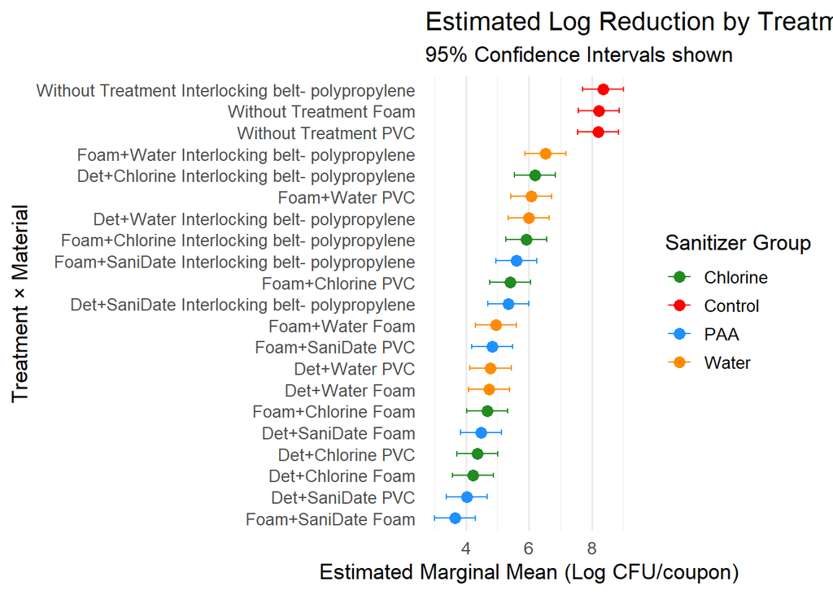

```r
ggplot(emm_df, aes(x = emmean, y = treatment_material, color = group)) +
  geom_point(size = 3) +
  geom_errorbarh(aes(xmin = lower.CL, xmax = upper.CL), height = 0.25) +
  scale_color_manual(values = c("Chlorine" = "forestgreen", "PAA" = "dodgerblue", "Water" = "darkorange", "Control" = "red", "Other" = "gray50")) +
  labs(
    x = "Estimated Marginal Mean (Log CFU/coupon)",
    y = "Treatment × Material",
    color = "Sanitizer Group",
    title = "Estimated Log Reduction by Treatment and Surface Type",
    subtitle = "95% Confidence Intervals shown"
  ) +
  theme_minimal(base_size = 13) +
  theme(axis.text.y = element_text(size = 10), panel.grid.major.y = element_blank())
```

#Answer: ##The plot of estimated marginal means clearly shows that sanitizer type and surface material substantially influenced the inactivation of L. monocytogenes.

##Control treatments (red) had the least reduction, confirming expected results.

##Treatments involving chlorine (green) and peracetic acid (PAA) (blue) generally resulted in greater log reductions, particularly on Foam and PVC.

##This graphical summary supports the significant main effects and interaction found in the ANOVA, and highlights that sanitizing efficacy is not uniform across surface types or agents. These results justify the use of pairwise post hoc comparisons to identify which combinations significantly differ from each other.

# 12 10. BONUS: Plot Mean Log CFU by Treatment and Material

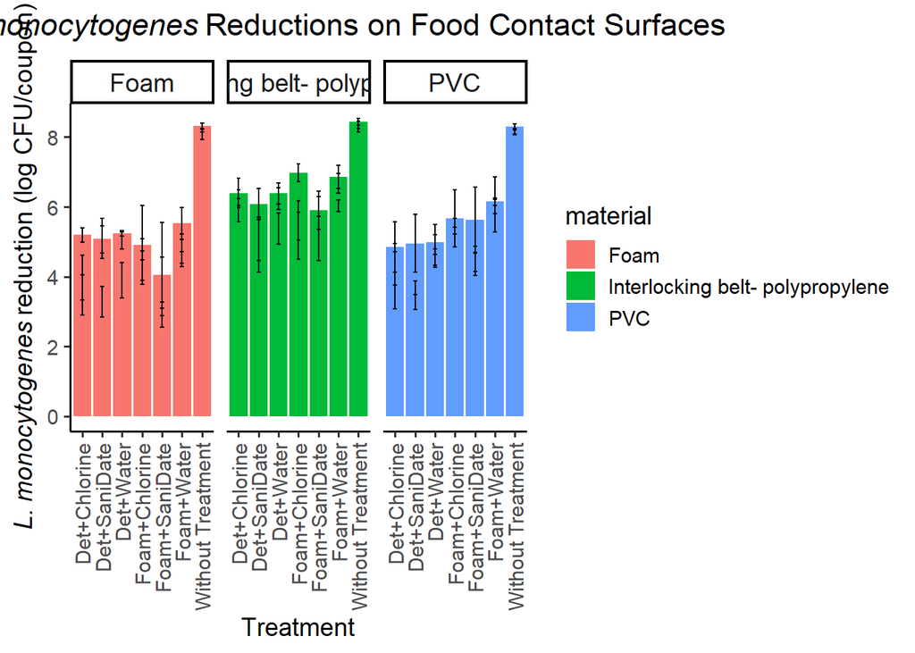

```r
data_clean$material <- gsub("Interlocking belt- polypropylene",
                            "Interlocking belt-\npolypropylene",
                            data_clean$material)

ggplot(summary_stats, aes(x = treatment, y = mean_log_cfu, fill = material)) +
  geom_bar(stat = "identity", position = position_dodge(width = 0.9)) +
  geom_errorbar(aes(ymin = mean_log_cfu - sd_log_cfu, ymax = mean_log_cfu + sd_log_cfu),
                width = 0.2, position = position_dodge(width = 0.9)) +
  facet_wrap(~ material) +
  labs(
    title = expression(italic("Listeria monocytogenes")~"Reductions on Food Contact Surfaces"),
    y = expression(italic("L. monocytogenes")~"reduction (log CFU/coupon)"),
    x = "Treatment"
  ) +
  theme_classic(base_size = 14) +
  theme(
    plot.title = element_text(hjust = 0.5, face = "bold"),
    strip.text = element_text(size = 14),
    axis.text.x = element_text(angle = 90, vjust = 0.5, hjust = 1)
  )
```

```r
ggsave("listeria_reduction_plotlv.png",
       width = 12, height = 6, dpi = 600)  # 600 DPI is print-quality
```

# 13 Results

Here is where the coding is going to happen, and it will be completely up to you. Include under this section as many sub-sections (using ##) and as many chunks needed to create the analytical workflow for your analysis, starting at loading packages and data, wrangling, EDA, modeling, assumptions checking, ANOVA table, means, pairwise comparisons, and final publication-quality plot.

Make sure to run a model that reflects your study design. Even if your study design does not include one of the designs covered in class, you are still expected to run the most appropriate model. If you need help for references, let me know.

Before each chunk, describe the steps being performed in that chunk. For example, “Here I will load the data”.

If a chunk produces output, like printing a data frame, statistical summary, a plot, ANOVA table, etc., make sure to write text interpreting what you see and how you can/will use that information to move forward to the next steps in the workflow.

*Results*

#Answer #This bar plot illustrates the mean log reductions of L. monocytogenes (± SD) across seven treatment types and three surface materials: Foam, Interlocking Belt-Polypropylene, and PVC.

#Foam : Greater variability in responses, but Without Treatment led to the highest bacterial counts (lowest reduction).

# 14 Team work in GitHub

Whether you are working with your future-self or as duos, make sure to stage, commit, and push after finishing each of the sub-sections above. When committing, write commit messages that are short and descriptive (e.g., finished wrangling).

If you are working in duos, make sure to split the workload. I will check your collaborative work through the commit history, and if one student has contributed significantly more than the other, than that will impact grades.

**Tip 1**: to avoid merge conflicts, make sure to **pull** first, and then start working locally. That will ensure that any changes made by your partner will be “downloaded” before you make changes to the files locally.

**Tip 2**: make use of the Issues on this repository to set up to-do lists and assign tasks to different people. You can also use each issue/task to discuss how things should be run and get to an agreement.

# 15 Submitting your work

Once you have developed all the code and answers, make sure to Render this quarto file.

**Notes on rendering**:

- Make sure to render your work and inspect how the final html look like.
- If it does not look professional for whatever reason, then fix the issue, re-render it, recheck.
- Only send me your work once your html file looks professional.
- Some potential issues you may encounter and how to fix them:
  - Some times your code may be creating a table output that is waaay to long and cumbersome to scroll through when rendered. If this is the case, make it more professional looking by using the `head()` function to only print the first handful of rows (instead of thousands of rows).
  - **DO NOT** delete the file’s heading levels (# and ##). They set up the proper heading 1 and 2 levels, and I use them to guide my grading.
  - If a given chunk is also outputting warnings or messages, inhibit this behavior by changing the chunk options `message` and `warning` to `FALSE`.
  - If, after rendered, 2 lines of text are connected and you wish to “break line” between them, add 2 extra spaces after the first one.

After rendering, an .html file will be created on your `code` folder.

Rename this file to `LASTNAME1-LASTNAME2_finalproject.html`.  
For ex., `Bastos-Mendes_finalproject.html`.

Submit the html file on eLC by **April 30th** 11:59 pm.